# CadenaCritica 09

ruta tradicional de 6 actividades; compromiso 36 frente a 43 días

# Enunciado

Un proyecto puede programarse de dos maneras. Para cada actividad, su responsable ha dado una estimación **segura** (con la que cumpliría aproximadamente nueve de cada diez veces, el percentil 90) y una estimación **agresiva pero alcanzable** (la mediana, el percentil 50), ambas en días. Las actividades no comparten recursos.

- **Cronograma tradicional**: estimaciones seguras, cada actividad con su fecha de inicio (la más temprana); el responsable empieza en esa fecha (no antes, aunque pueda) y, por la ley de Parkinson, nunca entrega antes de su estimación segura: si termina antes, no lo comunica.
- **Cadena crítica**: estimaciones agresivas, colchones por cortar y pegar (redondeados al día superior); las actividades de la cadena empiezan en cuanto terminan sus predecesoras (relevos) y las de alimentación no antes de su inicio del plan.

1. Calcule la duración del cronograma tradicional y su ruta crítica. ¿Cuántas actividades tiene?

2. Obtenga el plan de cadena crítica: cadena, colchones y fecha comprometida.

3. Simule 20000 ejecuciones (semilla 7939) en las que las duraciones son independientes y lognormales, con mediana la estimación agresiva y percentil 90 la segura (σ del logaritmo = ln(segura/agresiva)/1,2816; constante si coinciden), en los dos regímenes. ¿Con qué probabilidad se cumple la fecha prometida en cada caso? Compare también las duraciones medias.

4. Si cada actividad cumple su estimación segura con probabilidad 0,9 de forma independiente, ¿qué probabilidad hay de que ninguna actividad de la ruta crítica tradicional la supere? Compárela con la simulada y explique por qué el cronograma tradicional, con un margen en cada actividad, protege tan poco la fecha de entrega.

Tabla 1: Cuadro de datos del enunciado (días)

| activity | predecessor | agresiva | segura |
| --- | --- | --- | --- |
| A | --- | 8 | 11 |
| B | --- | 9 | 12 |
| C | A,B | 2 | 4 |
| D | A | 4 | 7 |
| E | C,D | 4 | 7 |
| F | E | 5 | 7 |
| G | F | 5 | 8 |
| H | G | 2 | 3 |

El proyecto corresponde a la instalación de una planta fotovoltaica sobre cubierta; las actividades son las siguientes (las duraciones del cuadro están en días).

Tabla 2: Descripción de las actividades

|  | Descripción |
| --- | --- |
| A | Estudio de sombras y producción |
| B | Cálculo estructural de la cubierta |
| C | Tramitación de permisos |
| D | Acopio de módulos e inversores |
| E | Montaje de la estructura soporte |
| F | Colocación de módulos |
| G | Cableado de corriente continua |
| H | Instalación de inversores |

# Resolución

## Apartado 1

1. Calcule la duración del cronograma tradicional y su ruta crítica. ¿Cuántas actividades tiene?

[figure not shown]

Figura 1: Grafo PERT con las estimaciones seguras (cronograma tradicional)

Cálculo de los tiempos tempranos y tardíos de los sucesos paso a paso (avance con los botones):

paso 0 de 27

[figure not shown]

Tabla 3: Calendario del cronograma tradicional

[figure not shown]

Haz clic en un número de la tabla para ver cómo se calcula.

👆 **Interactivo:** haz clic en cualquier celda de la tabla para ver cómo se calcula (otro clic la deselecciona).

| Actividad | Duración | Inicio más temprano | Fin más temprano | Inicio más tardío | Fin más tardío | H total | H libre | H independiente |
| --- | --- | --- | --- | --- | --- | --- | --- | --- |
| A | 11 | 0 | 11 | 0 | 11 | 0 | 0 | 0 |
| B | 12 | 0 | 12 | 2 | 14 | 2 | 0 | 0 |
| C | 4 | 12 | 16 | 14 | 18 | 2 | 2 | 0 |
| D | 7 | 11 | 18 | 11 | 18 | 0 | 0 | 0 |
| E | 7 | 18 | 25 | 18 | 25 | 0 | 0 | 0 |
| F | 7 | 25 | 32 | 25 | 32 | 0 | 0 | 0 |
| G | 8 | 32 | 40 | 32 | 40 | 0 | 0 | 0 |
| H | 3 | 40 | 43 | 40 | 43 | 0 | 0 | 0 |

El cronograma tradicional dura **43 días**; ruta crítica A - D - E - F - G - H (6 actividades).

## Apartado 2

2. Obtenga el plan de cadena crítica: cadena, colchones y fecha comprometida.

|  | colchón del proyecto |
| --- | --- |
| cortar y pegar = 0,5·Σ márgenes | 0,5·(3 + 3 + 3 + 2 + 3 + 1) = 0,5·15 = 7.5 → 8 |

|  | arco | cadena de alimentación | colchón requerido | holgura disponible = inicio de la cadena − fin más temprano | colchón adoptado = mín(requerido, disponible) |
| --- | --- | --- | --- | --- | --- |
| CA1 | C → E | B - C | 0,5·(3 + 2) = 2.5 → 3 | 12 − 11 = 1 | 1 |

Cadena A - D - E - F - G - H (28 días), colchón del proyecto 8 días: compromiso **36 días**.

[figure not shown]

Figura 2: Gantt del plan de cadena crítica

## Apartado 3

3. Simule 20000 ejecuciones (semilla 7939) en las que las duraciones son independientes y lognormales, con mediana la estimación agresiva y percentil 90 la segura (σ del logaritmo = ln(segura/agresiva)/1,2816; constante si coinciden), en los dos regímenes. ¿Con qué probabilidad se cumple la fecha prometida en cada caso? Compare también las duraciones medias.

En el régimen tradicional cada actividad empieza en $\max$(su fecha del cronograma, fin de sus predecesoras) y dura $\max$(duración simulada, estimación segura): los adelantos se pierden y los retrasos se transmiten. En el de relevos, cada actividad de la cadena empieza al terminar sus predecesoras y dura lo que dura.

|  | tradicional (Parkinson) | cadena crítica (relevos) | relevos con la fecha tradicional |
| --- | --- | --- | --- |
| fecha prometida | 43 | 36 | 43 |
| P(cumplir) | 0.504 | 0.892 | 0.993 |
| duración media | 43.873 | 30.879 | 30.879 |
| percentil 90 | 45.824 | 36.208 | 36.208 |

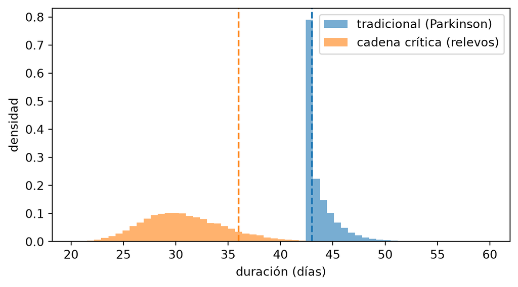

Figura 3: Duración simulada del proyecto en los dos regímenes

## Apartado 4

4. Si cada actividad cumple su estimación segura con probabilidad 0,9 de forma independiente, ¿qué probabilidad hay de que ninguna actividad de la ruta crítica tradicional la supere? Compárela con la simulada y explique por qué el cronograma tradicional, con un margen en cada actividad, protege tan poco la fecha de entrega.

La probabilidad de que ninguna de las 6 actividades de la ruta crítica supere su estimación segura es 0,9^6 = **0.531**. Con la ley de Parkinson y las fechas fijas, cualquier exceso de una actividad crítica retrasa el proyecto y ningún adelanto lo compensa, así que la probabilidad de cumplir no puede ser mayor que esa (la simulada es 0.504: también fallan las no críticas que se pasan de su holgura).

Cada estimación segura protege su actividad, no la fecha de entrega: el margen se pierde porque los adelantos no se transmiten (ley de Parkinson), porque quien tiene holgura empieza tarde (síndrome del estudiante) y porque en las convergencias manda el camino que llega más tarde. La cadena crítica retira esos márgenes y los concentra en colchones: promete 7 días antes y cumple con probabilidad 0.892. La última columna de la tabla muestra que el problema no estaba en las estimaciones: con las mismas duraciones, ejecutando por relevos, la fecha tradicional se cumpliría con probabilidad 0.993.

## Autoevaluación

Preguntas de respuesta múltiple con los datos de este ejercicio (la correcta, marcada con ✅, es la primera de cada lista). La celda las exporta también en formato GIFT, con las opciones barajadas, a `~/temp/cuestionario_cadena_critica.gift`, para importarlas en Moodle.

**1. Si cada una de las 6 actividades de la ruta crítica tradicional cumple su estimación segura con probabilidad 0,9, de forma independiente, ¿qué probabilidad hay de que ninguna la supere?**

- ✅ 0,531

- ◻️ 0,900

- ◻️ 0,400

- ◻️ 0,590

*0,9^6 = 0,531.*

**2. En la simulación del régimen tradicional con la ley de Parkinson, ¿con qué probabilidad se cumple la fecha prometida?**

- ✅ 0,50

- ◻️ 0,89

- ◻️ 0,90

- ◻️ 1,00

*0,504: como mucho 0,9^6, porque cualquier exceso en la ruta crítica se transmite y ningún adelanto lo compensa.*

**3. ¿Qué describe la ley de Parkinson?**

- ✅ el trabajo se alarga hasta ocupar el tiempo disponible: quien termina antes no lo comunica

- ◻️ con holgura, las actividades se empiezan en el último momento

- ◻️ en las uniones de caminos manda el que llega más tarde

- ◻️ repartir a una persona entre varias tareas las retrasa todas

*Las otras opciones son el síndrome del estudiante, el sesgo de convergencia y la multitarea.*